# Univariate-Linear-Regression

## Single variate linear regression with batch gradient descent

#### Process:

1. Import libraries (numpy, pandas, matplotlib)
2. Read data into DataFrame object
3. Implement cost function $J(\theta_{0},\theta_{1})$ for gradient descent
4. Run gradient descent to fit parameters $\theta$
5. Use cost function $h(\theta) = \theta_0 + \theta_1 x$ to predict *y* values

```python
# Importing necessary libraries

import numpy as np
import pandas as pd
import matplotlib.pyplot as plt
```

```python
# read text file into pandas DataFrame
df = pd.read_csv("ex1data1.txt", sep=",", header=None, names=["Population","Profit"])
print(df) # printing the data
```

```
    Population    Profit
0       6.1101  17.59200
1       5.5277   9.13020
2       8.5186  13.66200
3       7.0032  11.85400
4       5.8598   6.82330
..         ...       ...
92      5.8707   7.20290
93      5.3054   1.98690
94      8.2934   0.14454
95     13.3940   9.05510
96      5.4369   0.61705

[97 rows x 2 columns]
```

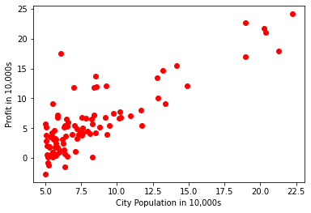

```python
# plotting our data, where our x-axis represents city population and our y-axis represents profit

fig = plt.figure() # initializes figure object
plt.plot(df["Population"], df["Profit"], 'ro')
plt.xlabel('City Population in 10,000s')
plt.ylabel('Profit in 10,000s')
```

Now, it's time to **initialize necessary vectors**.

We need:

- *X* - a matrix whose columns are different features of our data
- *y* - column vector whose entries are the final outputs of our training data
- $\theta$ - row vector whose entries are the different parameters to our hypothesis function

```python
X = df['Population'] # Create feature vector X
y = df['Profit'] # Create y vector

# create a vector of theta parameters, where the number of parameters is the number of features + 1
theta = np.zeros(shape=(1, df.shape[1]))
theta = pd.DataFrame(theta)

# bookkeeping dimensions
print(f"Dimensions of X are: {X.shape}")
print(f"Dimensions of y are: {y.shape}")
print(f"Dimensions of theta are: {theta.shape}")
```

```
Dimensions of X are: (97,)
Dimensions of y are: (97,)
Dimensions of theta are: (1, 2)
```

It's almost time to run gradient descent!

We just need to define our **cost function** $J(\theta)$ as follows: $$ J(\theta) = \frac{1}{2m}\sum_{i=1}^{m}(h_{\theta}((x^{(i)})-y^{(i)})^{2} $$

where $m$ is the number of training examples, $h_{\theta}(x^{i}) = \theta_{0}+\theta_{1}x^{(i)}$ is our hypothesis function, and the superscript $(i)$ represents the value corresponding to the $i^{\textrm{th}}$ training example.

$J(\theta)$ should return a scalar value.

```python
J = 0 # initializes our cost function J


# computes the summation part of J
for i in range(df.shape[0]):
    J += (theta[0] + (theta[1] * X[i]) - y[i]) ** 2

J = J / (2 * df.shape[0])
```

Now that we have our cost function all set up, the only thing we need to do now is **run gradient descent!**

Our gradient descent algorithm repeats the following assignment until convergence: $$\theta_{j} := \theta_{j} - \frac{\partial}{\partial \theta_{j}}J(\theta_{0},\theta_{1})$$ (for $j=0$, $j=1$)

and after evaluating the partial derivatives, we get that our algorithm repeats the following *simultaneous* assignments until convergence:

$$\theta_{0} := \theta_{0} - \alpha\frac{1}{m}\sum_{i=1}^{m}(h_{\theta}(x^{(i)})-y^{(i)})$$

and $$\theta_{1} := \theta_{1} - \alpha\frac{1}{m}\sum_{i=1}^{m}(h_{\theta}(x^{(i)})-y^{(i)})\cdot x^{(i)}$$

(If we were to update $\theta_{0}$ and $\theta_{1}$ procedurally, our psuedo-gradient function would actually still work, but it wouldn't be considered gradient descent.)

```python
#### Implementing gradient descent ####
%matplotlib inline

# number of iterations
iter = 1000

# learning rate
alpha = 0.01

for i in range(iter):
    temp_theta = theta

    ### updating theta_0 ###
    sum_1 = 0 # the value of the summation for theta_0
    for j in range(df.shape[0]):
        sum_1 += ((theta.iloc[:,0] + theta.iloc[:,1] * X.iloc[j]) - y.iloc[j])
    theta.iloc[:,0] = temp_theta.iloc[:,0] - ((alpha / df.shape[0]) * sum_1)


    ### updating theta_1 ###
    sum_2 = 0 # the value of the summation for theta_0
    for j in range(df.shape[0]):
        sum_2 += (((theta.iloc[:,0] + theta.iloc[:,1] * X.iloc[j]) - y.iloc[j]) * X.iloc[j])
    theta.iloc[:,1] = temp_theta.iloc[:,1] - ((alpha / df.shape[0]) * sum_2)
```

Now that we've fit our parameter vector $\theta$, let's use it in our hypothesis function $h_{\theta}$ to make predictions of profits based on a given city population!

For example, we will predict the profit corresponding to a city population of 150,000 using our hypothesis function $h_{\theta}$:

```python
predicted_profit = float(theta.iloc[:,0]) + float(theta.iloc[:,1]) * 15
print(predicted_profit)
```

```
13.674564953851512
```

Finally, replotting our original training data, but now with the hypothesis function $h_{\theta}$ plotted in blue and our predicted value plotted in yellow, we get:

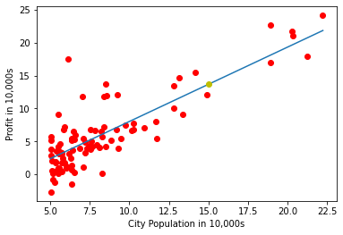

```python
x = np.arange(5.0, 22.5, .25)
theta_0 = float(theta.iloc[:,0])
theta_1 = float(theta.iloc[:,1])

fig = plt.figure() # initializes figure object
plt.plot(df["Population"], df["Profit"], 'ro')
plt.plot(x, theta_0 + theta_1 * x)
plt.plot(15, predicted_profit, 'yo')
plt.xlabel('City Population in 10,000s')
plt.ylabel('Profit in 10,000s')
```

## Voila!

We've successfully implemented univariate linear regression. The next step would be to implement multivariate linear regression to make predictions based on multiple features, but that's for another time...